# NathanGarrity_Lab1

## Lab 1 - Univariate Linear Regression on the California Housing Prices

Nathan Garrity (Student number: 8767594)

### **Introduction**

The goal of this report is to train a machine learning model using an univariate linear regression model.

I will be analysing 3 key variables and their relationship with median house value:

- Median income
- Population
- Number of households

Using linear regression analysis we can determine how each of these factors can influence median house value. The report will include an brief introduction to the dataset, cleanup of missing entries, modelling, an evaluation of the analysis, and a conclusion. The conclusion of the report will determine which of the three variables compared to house value provides the most relevent model.

### **Data Exploration**

Column Names:

- longitude
- latitude
- housing_median_age
- total_rooms
- total_bedrooms
- population
- households
- median_income
- median_house_value
- ocean_proximity

### **Data Preprocessing**

```python
import pandas as pd
import seaborn as sns
import matplotlib.pyplot as plt

df = pd.read_csv("housing.csv")
```

There are some values missing in the total_bedrooms column, though this column is not required for this report I will clean it for any potential future use. To clean the dataset, I took any null values and filled them with the median.

```python
# Checking for missing values in the dataset
missing_values = df.isnull().sum()

# To clean the dataset I filled missing values using the median of 'total_bedrooms'
df['total_bedrooms'].fillna(df['total_bedrooms'].median(), inplace=True)

# Confirm missing values are handled
cleaned_missing_values = df.isnull().sum()

# Display a list of the updated columns displaying count of corrected column entries
missing_values, cleaned_missing_values
```

```
(longitude               0
 latitude                0
 housing_median_age      0
 total_rooms             0
 total_bedrooms        207
 population              0
 households              0
 median_income           0
 median_house_value      0
 ocean_proximity         0
 dtype: int64,
 longitude             0
 latitude              0
 housing_median_age    0
 total_rooms           0
 total_bedrooms        0
 population            0
 households            0
 median_income         0
 median_house_value    0
 ocean_proximity       0
 dtype: int64)
```

### **Modeling**

```
          longitude      latitude  housing_median_age   total_rooms  \
count  20640.000000  20640.000000        20640.000000  20640.000000
mean    -119.569704     35.631861           28.639486   2635.763081
std        2.003532      2.135952           12.585558   2181.615252
min     -124.350000     32.540000            1.000000      2.000000
25%     -121.800000     33.930000           18.000000   1447.750000
50%     -118.490000     34.260000           29.000000   2127.000000
75%     -118.010000     37.710000           37.000000   3148.000000
max     -114.310000     41.950000           52.000000  39320.000000

       total_bedrooms    population    households  median_income  \
count    20640.000000  20640.000000  20640.000000   20640.000000
mean       536.838857   1425.476744    499.539680       3.870671
std        419.391878   1132.462122    382.329753       1.899822
min          1.000000      3.000000      1.000000       0.499900
25%        297.000000    787.000000    280.000000       2.563400
50%        435.000000   1166.000000    409.000000       3.534800
75%        643.250000   1725.000000    605.000000       4.743250
max       6445.000000  35682.000000   6082.000000      15.000100

       median_house_value
count        20640.000000
mean        206855.816909
std         115395.615874
min          14999.000000
25%         119600.000000
50%         179700.000000
75%         264725.000000
max         500001.000000
```

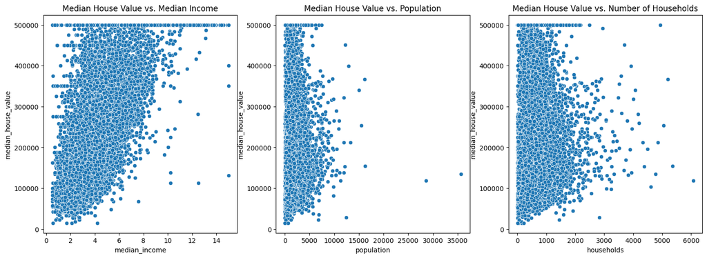

```python
## Step 3
# Explore statistics using describe function
statistics = df.describe()
print(statistics)

# Scatter plots between median house value and independent variables
fig, axes = plt.subplots(1, 3, figsize=(18, 6))

# Scatter plot 1: Median House Value vs. Median Income
sns.scatterplot(x='median_income', y='median_house_value', data=df, ax=axes[0])
axes[0].set_title('Median House Value vs. Median Income')

# Scatter plot 2: Median House Value vs. Population
sns.scatterplot(x='population', y='median_house_value', data=df, ax=axes[1])
axes[1].set_title('Median House Value vs. Population')

# Scatter plot 3: Median House Value vs. Number of Households
sns.scatterplot(x='households', y='median_house_value', data=df, ax=axes[2])
axes[2].set_title('Median House Value vs. Number of Households')

plt.show()
```

Describing the 4 variables:

- Median house value - The dependent variable in the scatter plots, representing house prices with a range between $14,999 to $500,001. Based on the scatter plot graphs we see that a high quantity of houses are valued at $500,001, we can assume that the data cuts off for any house valued over $500,001.
- Median income - A variable which represents average income in an area, ranging between 0.5 to 15.0. It displays a postive trend when compared with median house value.
- Population - A variable which represents the total population in a region, with wide range from 3 to 35,682, with no strong correlation with house value when viewing the scatterplot.
- Households - Represents the total number of households, with values between 1 and 6,082, showing no obvious correlation with house value in the scatter plot.

```python
## Step 4 - Run three linear regressions (fitting)

# Import necessary modules from scikit-learn
from sklearn.linear_model import LinearRegression
from sklearn.model_selection import train_test_split
from sklearn.metrics import mean_squared_error

# Prepare the independent variables (income, population, housholds) and the dependent variable (median house value)
X_income = df[['median_income']]
X_population = df[['population']]
X_households = df[['households']]
y = df['median_house_value']

# Split the dataset into training and testing sets for each variable
# 80% of the data will be used for training, and 20% will be reserved for testing (test_size=0.2)
X_train_income, X_test_income, y_train, y_test = train_test_split(X_income, y, test_size=0.2, random_state=42)
X_train_population, X_test_population, _, _ = train_test_split(X_population, y, test_size=0.2, random_state=42)
X_train_households, X_test_households, _, _ = train_test_split(X_households, y, test_size=0.2, random_state=42)

# Initialize and train the linear regression model for median income, population and households
model_income = LinearRegression()
model_income.fit(X_train_income, y_train)
model_population = LinearRegression()
model_population.fit(X_train_population, y_train)
model_households = LinearRegression()
model_households.fit(X_train_households, y_train)

# Predict the target values (median house value)
y_predict_income = model_income.predict(X_test_income)
y_predict_population = model_population.predict(X_test_population)
y_predict_households = model_households.predict(X_test_households)

# Calculate the Mean Squared Error (MSE) to evaluate  accuracy of each model's predictions
mse_income = mean_squared_error(y_test, y_predict_income)
mse_population = mean_squared_error(y_test, y_predict_population)
mse_households = mean_squared_error(y_test, y_predict_households)

# Output the MSE for each model to compare their performance
print(f'MSE (Income): {mse_income}')
print(f'MSE (Population): {mse_population}')
print(f'MSE (Households): {mse_households}')
```

```
MSE (Income): 7091157771.76555
MSE (Population): 13102870667.503983
MSE (Households): 13035578954.783041
```

```python
## Step 5

from sklearn.metrics import mean_absolute_error

mae_income = mean_absolute_error(y_test, y_pred_income)
mae_population = mean_absolute_error(y_test, y_pred_population)
mae_households = mean_absolute_error(y_test, y_pred_households)

# Intercepts and slopes for income, population, and households
intercept_income = model_income.intercept_
slope_income = model_income.coef_[0]

intercept_population = model_population.intercept_
slope_population = model_population.coef_[0]

intercept_households = model_households.intercept_
slope_households = model_households.coef_[0]

# Display results in a single table
results = pd.DataFrame({
    'Model': ['Income', 'Population', 'Households'],
    'Intercept': [intercept_income, intercept_population, intercept_households],
    'Slope': [slope_income, slope_population, slope_households],
    'MSE': [mse_income, mse_population, mse_households],
    'MAE': [mae_income, mae_population, mae_households]
})

print(results)
```

```
        Model      Intercept         Slope           MSE           MAE
0      Income   44459.729169  41933.849394  7.091158e+09  62990.865301
1  Population  210970.696345     -2.647127  1.310287e+10  90588.877725
2  Households  197526.369197     19.337155  1.303558e+10  90218.258138
```

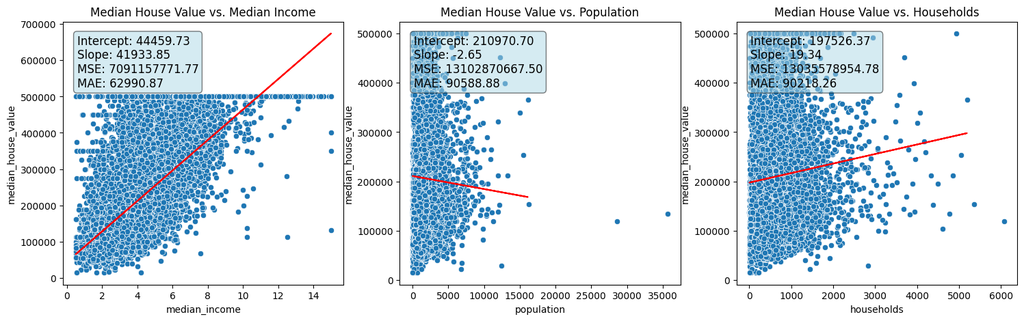

```python
# Function to add text box with regression parameters and metrics
def add_regression_info(ax, intercept, slope, mse, mae, variable_name):
    textstr = '\n'.join((
        f'Intercept: {intercept:.2f}',
        f'Slope: {slope:.2f}',
        f'MSE: {mse:.2f}',
        f'MAE: {mae:.2f}'))
    # Text box
    ax.text(0.05, 0.95, textstr, transform=ax.transAxes, fontsize=12,
            verticalalignment='top', bbox=dict(boxstyle='round,pad=0.3', facecolor='lightblue', alpha=0.5))
    ax.set_title(f'Median House Value vs. {variable_name}')

# Scatter plot 1: Median House Value vs. Median Income
plt.figure(figsize=(18, 5))

plt.subplot(1, 3, 1)
sns.scatterplot(x='median_income', y='median_house_value', data=df)
plt.plot(X_test_income, y_pred_income, color='red')  # regression line
add_regression_info(plt.gca(), intercept_income, slope_income, mse_income, mae_income, 'Median Income')

# Scatter plot 2: Median House Value vs. Population
plt.subplot(1, 3, 2)
sns.scatterplot(x='population', y='median_house_value', data=df)
plt.plot(X_test_population, y_pred_population, color='red')  # regression line
add_regression_info(plt.gca(), intercept_population, slope_population, mse_population, mae_population, 'Population')

# Scatter plot 3: Median House Value vs. Number of Households
plt.subplot(1, 3, 3)
sns.scatterplot(x='households', y='median_house_value', data=df)
plt.plot(X_test_households, y_pred_households, color='red')  # regression line
add_regression_info(plt.gca(), intercept_households, slope_households, mse_households, mae_households, 'Households')

plt.show()
```

### **Evaluation**

##### Median House Value vs. Median Income

- **Positive** correlation (higher median income, higher median house value)
- **Large/Steep** slope (41933.85), indicating a very strong effect on house value based on income
- **High** MSE and MAE imply significant variance despite strong correlation, other factors also have an impact on house value

##### Median House Value vs. Population

- **Negitive** correlation
- **Small/Weak** slope, indicating little to no effect on house value based on population
- **High** MSE and MAE as well as negitive and weak slope imply that population alone is not an ideal predictor of house values

##### Median House Value vs. Households

- **Positive** correlation
- **Small/Weak** slope, indicating a tiny increase on house value based on household count (House value increases by $19.34 per household)
- **High** MSE and MAE similar to the other scatter plot graphs, indicating that multiple other factors are influencing house value besides household number

##### In Summary

Population and household numbers have little to no impact on house prices, the large mean squared errors and mean absolute errors in all models indicate that other factors not shown here could be important in further predicting house values.

### **Conclusion**

To conclude the report, **the model with the best fit is clearly *Median House Value vs. Median Income***. This model is the most consistant with proving correlation, whereas the other two models which compare house value to population and households have poor correlation, small and insignificant slopes, and reletively higher MSE and MAE. The model comparing income displays a steep upwards slope with positive correlation which sets it apart from the other two variable models. The households models displays lesser correlation, but a positive slope, for every household the house value increases $19.34, which is small in relation to the value range. The population model has negitive correlation and slope, making the households model the second best fit, and the population model the worst fit. These 2 models have a significantly lower predictive power with higher MSE and MSE in comparison to the better fit, house value vs income.

##### Brief Insight:

It's important to reiterate that while the model comparing house value to income is the most relevent in this evaluation of 3 models, the MSE and MAE are still high. This indicates income isn't a sole factor that inceases house value, developing models on other variables such as total rooms or total bedrooms could be looked at as those factors could be more related to the value of a home.